# Are Female Workers Payed Equally?

Group 3: Lorenzo Wahaus, Sonia Duan, Jingrui Zhou

2022-03-13

# Introduction

Tracing back to the early 20th century, most women in the United States only stayed at home taking care of babies or housekeeping. Even those who worked outside the home were primarily unmarried. **Women were trapped in homes at that time**. However, people often understate their contributions to the economy beyond family caring. According to our background research, we found that despite of **the limited opportunities available for women**, their participation in the economy still continued to rise between the mid 20 century.

Nowadays, with more and more female workers entering the workforce than ever before, **we are interested in the wage equality between males and females**. When women became more aware of their own circumstances in their careers as well as their families, they began to **pay more attention on their own rights and benefits**. We want to focus on the gender equality of income levels in the project.

So we located a data set that was created from the Census Bureau and Bureau of Labor Statistics surveys. The information gathered is based on American jobs and the earnings of persons who work in such jobs. Searching the background information of the original data set, we found that the United States Census Bureau and the Bureau of Labor Statistics takes surveys of people, their jobs and their earnings. The data set that we’re working with is based on job data from 2013 to 2016, containing a sample of 2088 data cases.

The full url for the original data set is: “https://raw.githubusercontent.com/rfordatascience/tidytuesday/master/data/2019/2019-03-05/jobs_gender.csv”, and we found the data at: “https://github.com/rfordatascience/tidytuesday/blob/master/data/2019/2019-03-05/jobs_gender.csv”.

We then created a code book of the variables that we planned to use to build each of our models.

| Variable | Categorical or Numeric | description |
| --- | --- | --- |
| year | numeric | year the data point is from |
| major_category | categorical | Large category that best fits the job of the data point |
| workers_female | numeric | Estimated total of female workers in the job |
| percent_female | numeric | Estimated percent of total workers in the job that are female |
| total_earnings | numeric | Estimated median earning for all workers in the job |
| total_earnings_female | numeric | Estimated median earnings for female workers in the job |
| wage_percent_of_male | numeric | Wages of female workers as a percent of male workers |

For our modified data set, we removed the variables that we didn’t use in the model building. Also, we re-coded the `major_category` variable. In the original data set it was a long string of multiple words, we cut it down to one word each to help conserve space on our visuals that used `major_category` as a variable.

For our **response variable**, we chose `wage_percent_of_male`.

We used it to compare the female workers income levels with those of male workers. It depicts female workers’ wages as a percentage of male workers’ wages. We can simply determine whether the gender wage equality is changing by evaluating the relationship between `wage percent of male` and other relevant variables.

**We want to discuss about the states of the women in their career basing on their income levels in comparison to men**. As people who wish the living conditions of females to improve in the United States, we believe it’s a meaningful topic to discuss about. Because you cannot have gender equality if one gender is being payed less for their work.

# Model Building

## Model proposed by Lorenzo

One of the first variables that I thought of using to predict `wage_percent_of_male` was `percent_female`. This is because the more women there are in a job, the larger of a voice they have among the workers, and the percent of workers in a job that are female was one of the ways to measure that. Looking at the 95% confidence interval for a bootstrap differential of the slope with 10000 repetitions of the original data, both the upper bound and lower bound are positive. This means that there is a positive relationship between `percent_female` and `wage_percent_of_male`, and thus `percent_female` will be used in constructing my model.

```
## # A tibble: 1 × 2
##   lower_ci upper_ci
##      <dbl>    <dbl>
## 1  0.00875   0.0689
```

### Year

I also know that based on historical trends, women’s wages have historically been less than men, with a trend towards wage equality. Although our data only has four years, I wanted to know if it also reflected this trend and could give me another variable for my model. I ran into an issue when making the box plot, where it would not separate based on year, so I had to make a new temporary variable `year_category` for the box plot. Looking at the box plot, the median `wage_percent_of_male` appears to increase each year, with the exception of 2016 having a slightly lower median than 2015. But, the general trend is still there, so I will be using year as my second variable.

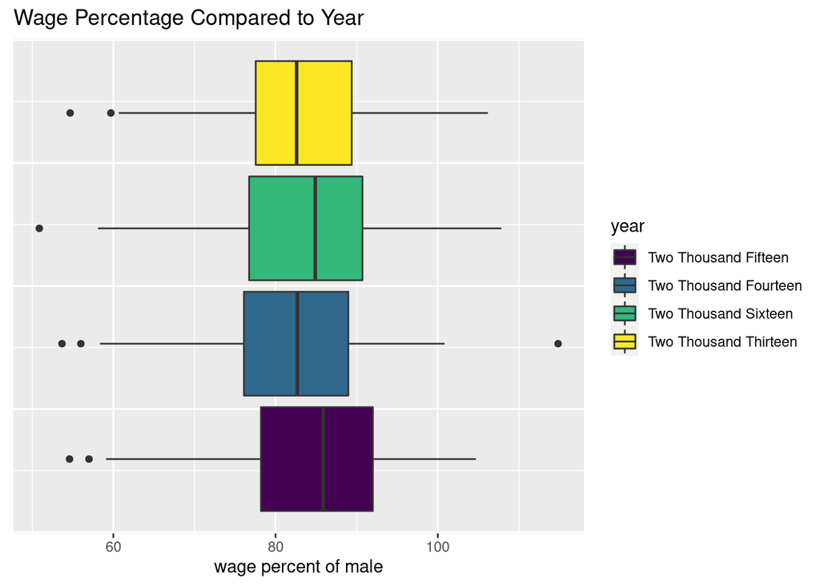

### Category of Job

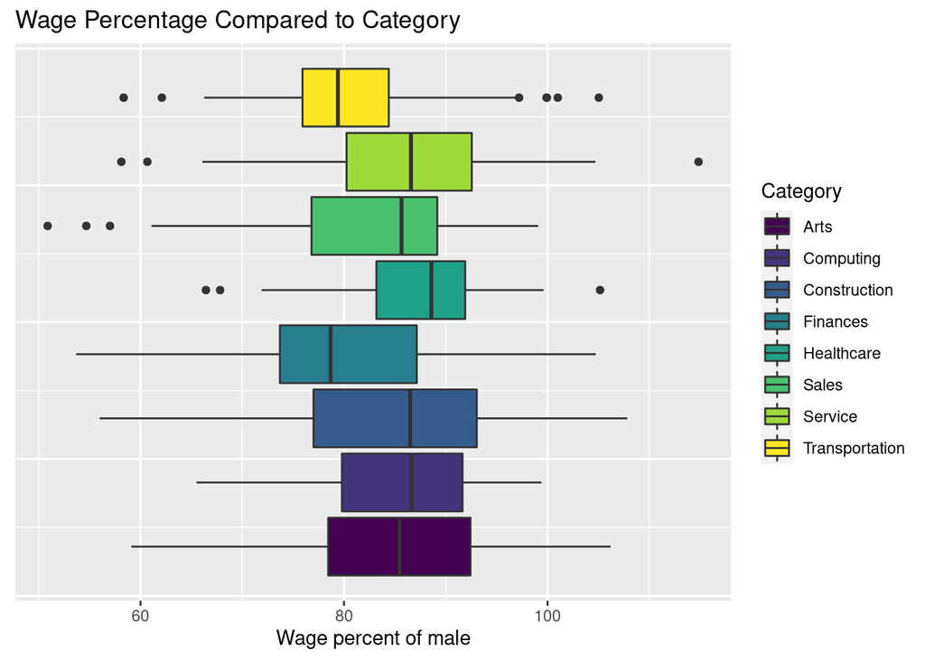

### Building my Model

Combining all of my variables into a single linear model gets the equation:

wage_percent_of_male-hat = -828 + (0.046 * percent_female) + (0.452 * year) + (2.09 * Computing) + (1.80 * Construction) + (-4.71 * Finances) + (1.88 * Healthcare) + (-2.20 * Sales) + (1.46 * Service) + (-3.39 * Transportation)

```
## # A tibble: 10 × 5
##    term                          estimate std.error statistic p.value
##    <chr>                            <dbl>     <dbl>     <dbl>   <dbl>
##  1 (Intercept)                  -828.      680.        -1.22  0.224
##  2 percent_female                  0.0460    0.0188     2.45  0.0145
##  3 year                            0.452     0.337      1.34  0.181
##  4 major_categoryComputing         2.09      1.68       1.24  0.214
##  5 major_categoryConstruction      1.80      2.04       0.883 0.378
##  6 major_categoryFinances         -4.71      1.45      -3.25  0.00121
##  7 major_categoryHealthcare        1.88      1.73       1.09  0.278
##  8 major_categorySales            -2.20      1.42      -1.55  0.122
##  9 major_categoryService           1.46      1.46       0.997 0.319
## 10 major_categoryTransportation   -3.39      1.60      -2.12  0.0348
```

## Model proposed by Jingrui

### Choosing Of Variables:

The variables we are using here are the `total_earnings`(numeric variable), `total_earnings_female`(numeric variable), and `major_category`(categorical variable). The reason why I choose to use these variable is that in order to predict the `wage_percent_of_male`, we could infer that the amount of money that males have got is obviously the total earnings minus earnings from females. Therefore, we could hypothesize that there are correlations between the `wage_percent_of_male` and those variables I have mentioned above.

### Finding Relationships

Firstly, we should probably focus on the fact that whether there is any relationship between the `total_earnings` and the `total_earnings_female` by creating a graph out of that. We should keep in mind that since there is different categories of job, we should look at them separately.That’s the reason why I choose to use a facet as the output since it could separate the categories of carrer into a clearer form.

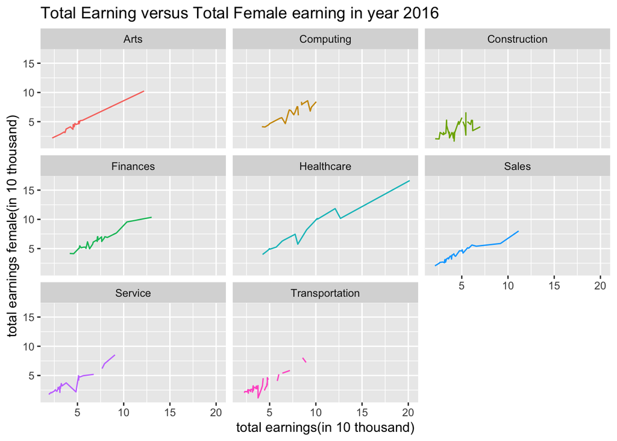

It’s obvious that the those two variable we are using got a positive relationships with each other but with different slope showing the level of importance, or to say, the role of female in that job_category. By looking at it’s slope we can therefore have the sense on what should we expect that how many are female worker earning, and thus to predict the `wage_percent_of_male` due to the fact that money are earned one or another, it’s clear that they got correlation.

[figure not shown]

### Building Model

Turning my variables into a **single linear model** gives us the equation of *wage_percent_of_male-hat = 80.97 + (0.00168 * total_earnings_female) + (-0.00148 * total_earnings + (1.92 * Computing) + (4.63 * Construction) + (-3.072 * Finances) + (-1.25 * Healthcare) + (-0.567 * Sales) + (3.341 * Service) + (0.119 * Transportation)*

```
## # A tibble: 10 × 5
##    term                         estimate std.error statistic   p.value
##    <chr>                           <dbl>     <dbl>     <dbl>     <dbl>
##  1 (Intercept)                  81.0     1.05         76.9   2.21e-311
##  2 total_earnings_female         0.00169 0.0000613    27.5   2.58e-108
##  3 total_earnings               -0.00148 0.0000521   -28.4   1.42e-112
##  4 major_categoryComputing       1.92    1.09          1.77  7.80e-  2
##  5 major_categoryConstruction    4.63    1.24          3.75  1.94e-  4
##  6 major_categoryFinances       -3.07    0.965        -3.18  1.54e-  3
##  7 major_categoryHealthcare     -1.25    1.21         -1.03  3.02e-  1
##  8 major_categorySales          -0.567   0.944        -0.600 5.48e-  1
##  9 major_categoryService         3.34    0.991         3.37  7.96e-  4
## 10 major_categoryTransportation  0.120   1.06          0.113 9.10e-  1
```

## Models Comparison

[output not shown]

# Results

Comparing the adjusted R-squared and RMSE of our models compared to the test data reveals that Jingrui’s model is clearly the best. His model had the highest adjusted R-squared when it came to comparing it to the training data, and had the lowest RMSE when compared to the testing data.

Fitting Jingrui’s model to the entire data set gets us the predictive model of: wage_percent_of_male^ = 81.060 - 0.001 * total_earnings + 0.002 * total_earnings_female + 0.586 * Computing + 4.444 * Construction - 3.821 * Finances - 1.013 * Healthcare - 0.587 * Sales + 2.913 * Service - 0.843 * Transportation

Intercept: Without considering the major category, when total earnings and total earnings female are both equal to 0, the predicted wage percent of male is 81.060, on average.

Slope-Total Earnings Female: Holding everything else the same, when the median female earnings for all workers in the job increases by 1, the wage percent of male is expected to increase by 0.002, on average.

Slope-Major Category: Holding everything else the same, depending on the major category, the predicted wage percent of male is expected to change differently. When female is working in **Computing** area, the predicted wage percent of male is has an **increase of 0.586**, on average. When female is working in **Construction** area, the predicted wage percent of male is has an **increase of 4.444**, on average. When female is working in **Finances** area, the predicted wage percent of male is has a **decrease of 3.821**, on average. When female is working in **Healthcare** area, the predicted wage percent of male is has a **decrease of 1.013**, on average. When female is working in **Sale** area, the predicted wage percent of male is has a **decrease of 0.587**, on average. When female is working in **Service** area, the predicted wage percent of male is has an **increase of 2.913**, on average. When female is working in **Transportation** area, the predicted wage percent of male is has a **decrease of 0.843**, on average.

```
## # A tibble: 10 × 5
##    term                         estimate std.error statistic   p.value
##    <chr>                           <dbl>     <dbl>     <dbl>     <dbl>
##  1 (Intercept)                  81.1     0.750       108.    0
##  2 total_earnings               -0.00146 0.0000378   -38.6   4.89e-214
##  3 total_earnings_female         0.00168 0.0000447    37.5   2.53e-206
##  4 major_categoryComputing       0.586   0.745         0.786 4.32e-  1
##  5 major_categoryConstruction    4.44    0.911         4.88  1.21e-  6
##  6 major_categoryFinances       -3.82    0.677        -5.64  2.06e-  8
##  7 major_categoryHealthcare     -1.01    0.842        -1.20  2.29e-  1
##  8 major_categorySales          -0.587   0.669        -0.877 3.81e-  1
##  9 major_categoryService         2.91    0.702         4.15  3.54e-  5
## 10 major_categoryTransportation -0.843   0.766        -1.10  2.72e-  1
```

```
## # A tibble: 1 × 2
##   adj.r.squared r.squared
##           <dbl>     <dbl>
## 1         0.585     0.588
```

```
## # A tibble: 1 × 3
##   .metric .estimator .estimate
##   <chr>   <chr>          <dbl>
## 1 rmse    standard        6.02
```

Looking at the best model fit to the full data set, we get an adjusted R^2 value of 0.5848, and the RMSE value of 6.0198. From the adjusted R^2, we found out that it shows a okay fit between the data and the model. However, it’s definitely not the best possible model for the data. And through the RMSE value, we can see that it may not predict the data accurately because the value is much larger than we expected for a model which is a good fit.

As the scientific question we’ve discussed in the introduction, we could see that the initial expectation of the wages for male are expected to be higher than female, which could somehow support the saying that the female do got relatively lower position in their career basing on their income levels in comparison to men(not specifically, but in average).

…